# A big data analytics model for customer churn prediction in the retiree segment - ScienceDirect

### 4.3. Population

The target population for this study consists of all mass and non-mass affluent clients of the target bank between the ages of 50 to 71 years old, with one or more open and active products and who are not partially or fully retired at the beginning of the analytic window, as we want to observe the retirement event. This analysis is based on an Analytic Window from November 1, 2011, to September 30, 2015, to provide a large enough population in order to conduct behavior analysis.

Although the main purpose of this paper is to examine the churn behavior of mass-affluent clients, to address all the hypotheses; high-net-worth and non-mass affluent clients who share homogeneous characteristics, such as age or shopping behavior are also included in this study. The target population and universe are being used interchangeably throughout this paper.

#### 4.3.1. Age criteria

The first criteria for the target population selection are based on the critical ages for retirement, for instance, age 50 is identified as the retirement age for most of the personal clients who own a business and when their business transactions begin to decrease. On the other hand, 55, 60 and 65 are the critical ages for personal clients who are identified, based on the first deposit of pension payouts into their Direct Deposit Accounts (DDA) or transferring Registered Retirement Savings Plan (RRSP) funds into a Registered Retirement Income Fund (RRIF) or any other type of retirement income fund. In order to validate the retirement age, currently retired clients of target banks are examined and segmented, based on their age and also transaction accounts.

#### 4.3.2. Exclusions criteria

Based on the age criteria, the initial population included more than 3 million clients. Though, further analysis revealed that more consideration is required to minimize the bias in the dataset as much as possible. Therefore, the following exclusions are applied to the initial population of 3,144,132, to ensure there are sufficient observation months for the journey development during the analytic window (November 1, 2011, to September 30, 2015) to create the final universe for this study. A quick analysis of the target population revealed that the three months’ staying power of behavior models, which was discussed by Neslin et al. (2006) is also valid for our population. Therefore, the following criteria were applied to the initial Retirement Universe to exclude all the clients who had less than three months’ history.

**A**

Clients with retirement dates prior to February 1, 2012, OR retirement dates after June 30, 2015

**B**

Clients who attrited prior to February 1, 2012

**C**

Clients with fewer than 3 months of observations in the analytic window

**D**

Clients with <3 months of observations before retiring

**E**

Clients with <3 months of observations before attrition

**F**

Clients with <3 months of observations before the end of the analytic window

#### 4.3.3. Population segmentation

In order to assess the possibility of a correlation between attrition and customer loyalty, the retirement and attrition behaviors were captured through different ways in which each client joins the Universe. Therefore, the Analytic Universe is segmented, based on following three groups of clients: Existing Clients, New to the bank and also those clients who are new to the Universe.

**A**

**Existing Clients** who represent ∼ 92% of the Universe consist of all clients between the ages of 50–71, who have an existing banking relationship with the target bank as of Oct. 31, 2011, and joined the Universe as of Nov 1, 2011. This population includes active, personal clients who may or may not have a Direct Investing profile, and with at least one or more active/open products. This group does not include those who are already retired prior to Nov 1, 2011, or deceased clients.

**B**

**New to the Bank clients** who represent ∼ 3% of the Universe are those clients who joined the Universe during the Analytic Window and were not bank clients prior to Oct 31, 2011.

**C**

**New to the Universe** This category covers existing bank clients who did not reach the critical ages of retirement at the beginning of the analytic window, but later on became eligible to retire within the period of this study. This group represents ∼ 5% of the Universe.

## 5. The big data model

### 5.1. Structured and unstructured data

Big data has become a popular term to describe the exponential growth, availability and use of information, both structured and unstructured (SQL and NoSQL) (Alshammari, Bajwa, & Lee, 2015).

The structured and unstructured data for the target bank include the archival data on the client demographics and banking products to identify the research population; online data and Interactive Voice Response (IVR) data for the identified population. The online data is mostly the pixel data which tracks clients' behavior on various websites. The provided pixel data demonstrates, among others, how many times a client visited an external service or product, which is either offered or endorsed, by the target bank. This data also provides visibility on each client’s online usage.

### 5.2. Data limitation

There are two crucial and problematic challenges associated with churn data, the imbalance in the data distribution (Xie, Li, Ngai, & Ying, 2009) and the structure of data. The most important limitation in this study is the data related to the retirement and attrition status, especially for those who fall under the category of business clients or that retired at other financial institutes, as the current process is based on self-reported status, but apparently, many clients do not call the bank to change their status from employed to retired. Personal clients who have a Direct Deposit Account (DDA) can be identified as soon as the first CPP payment is made to their personal DDA accounts. However, business owners and other personal clients who do not hold a DDA account with the target bank are not easily detectable, mainly because most of the churners retain one or two active accounts with the target bank, while the majority of their retirement investment is already transferred to another financial institute. To address this limitation, the CLV measurement technique, as well as the calculation of Money-In (MI) balance, which is currently being used as an indicator to distinguish between active and passive clients, is used in this study to predict the retirement status. These techniques are discussed in the Retirement Consolidation Model.

### 5.3. Pattern recognition cues

In order to identify the retirement event and also the prediction of possible churn events, a wide range of cues was analyzed to identify the most relevant ones. Cues are categorized into four different groups: Life Style, Client Feedback, Information Seeking, and Behavioral cues.

After applying the above cues on the eligible population, it is first divided into two groups of retired and non-retired clients, and then each group would be further divided into two subgroups of retained and attrited; the outcome of this analysis is discussed in the results section. As stated in the data limitation section, the major obstacle in any retention planning strategy is to target the right clients. Since many churners retain at least one active account with the target bank while they have already transferred all of their investments out, it is very likely that some of the clients who were identified as retired and retained are already churned. As a result, implementing a consolidation model is necessary to differentiate loyal clients (those who retired and consolidated all their investment with the target bank) from the actual churners. This model is the subject of the next section of discussion.

### 5.4. Retirement consolidation model

In order to increase the accuracy rate of our findings and prevent any biases in data, the CLV and MI techniques are applied to the Retired and Retained (R&R) segment to separate loyal clients from churners and also, partially churned clients. Henceforth, the partially churned clients who can be considered as potential clients are labeled Committed at Risk, as their continuance relationship with the bank depends on their level of satisfaction, as well as the competence level of products offered by the target bank. The outcome of this investigation will help to reduce the churn rate after retirement and will increase the client's share of wallet to the optimal level.

Bauer, Hammerschmidt, and Braehler (2003) discussed a comprehensive formula for calculating the CLV for each client. Although they have used many different variables to calculate the revenue and also the cost of each client in a specific period, their recommended formula stems from three basic elements:

**I**

Client NPV (Net Present Value) over time = (all Revenues – all Costs)

**II**

Length of Service (LoS)

**III**

Discount Factors which is used in the NPV calculation

Although the calculation of the CLV is the preferred method for identifying the most valuable clients, the data for the population was collected only for the past three years; therefore the calculated value of the existing clients who form the majority of the population does not represent the actual values of these clients. To address the issue and eliminate any bias that may occur due to the flaw, the current Money-In balance is compared to the future Money-In balance, based on the forecasted cash flow technique over a period of 12 months. Hence, the change in MI balance 6 months prior to retirement (-6 months) and 6 months post-retirement (+6 months) is used to determine if the consolidation of assets occurred with the target bank or other financial institutes.

Money In (MI) balances include all the money a client holds in various accounts, such as Checkings/Savings/eSavings, Guaranteed Investment Certificates (GIC), Mutual Funds, and Direct Investing (stocks, ETFs, Mutual Funds, and so forth).

In order to categorize clients based on their MI, the first step is to define the criteria, such as the minimum/maximum balance and also the growth rate. Therefore, the result of this analysis revealed that those clients who have less than $4000 in their account for a period of 6 months, either before or after their retirement, are most likely inactive clients with no severe banking relationship with the target banks, regardless of retiring with it, meaning that these are already attrited. This analysis also revealed that clients who hold more than $10,000,000 in their balance for the above period are high net-worth clients who most likely will remain loyal. Thus, all the clients who fall under these two extreme categories were excluded from the study.

Further analysis shows that clients who increased their MI balance by more than 10% within 6 months post retirement are most likely to remain loyal and retained, whereas those who decreased their MI by more than 10% are in the process of attrition and migration to other financial institutes. Therefore, as illustrated in Fig. 9, clients with starting and ending MI balances between $4 M and $10 M are categorized based on the following:

**•**

If the MI balance increases by more than 10% then Consolidated with the target bank

**•**

If the MI balance decreases by more than 10% then Consolidated with OFI

**•**

If the MI balance increases/decreases by less than 10% then Committed Retirees

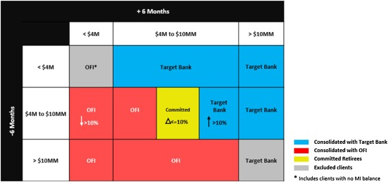

1. [Download : Download high-res image (173KB)](https://ars.els-cdn.com/content/image/1-s2.0-S0268401218301518-gr9_lrg.jpg)
2. [Download : Download full-size image](https://ars.els-cdn.com/content/image/1-s2.0-S0268401218301518-gr9.jpg)

Fig. 9. Schematic view of Retirement Consolidation Model.

## 6. Analysis and results

### 6.1. Big data analysis of client segmentation

After building a predictive model, it is essential to evaluate the performance of the classifiers. In order to assess the churn behavior, the following steps were applied to develop segmentation for the retirement journey analysis. The result of this segmentation is summarized in Fig. 10.

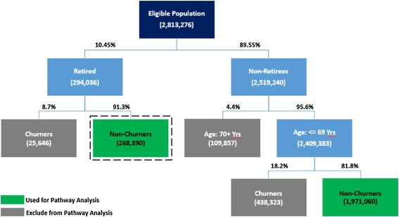

1. [Download : Download high-res image (184KB)](https://ars.els-cdn.com/content/image/1-s2.0-S0268401218301518-gr10_lrg.jpg)
2. [Download : Download full-size image](https://ars.els-cdn.com/content/image/1-s2.0-S0268401218301518-gr10.jpg)

Fig. 10. CRT analysis of Target Bank population.

As noted by Lemon et al. (2003), CRT, as depicted in Fig. 10, begins with one node (root) containing the entire sample and it then examines all possible splitting variables to the root by selecting the most different according to a binary tree pattern. By applying CRT to various groups within our sample, we were able to identify cues. As shown in Fig. 10, out of 2,813,276 clients, approximately 10.45% (294,036) fall under the retired group, while the remaining 89.55% of clients are part of the non-retirees sub-group.

Second, by utilizing attrition cues, each group is further divided into two sub-groups of "Churners" and "Non-Churners." The result of this analysis for retired clients revealed that 8.7% of those clients who retired with the target bank have already attrited. However, more dissection was necessary for the non-retirees group as some of the clients in this group were showing signs of being passive clients. As a result, about 109,857 clients, who account for 4.4% of non-retirees, are clients over the age of 70 with declining Money In balance. We assumed these clients have already retired with other financial institutes and are in the process of migrating to that financial institute. Therefore, these groups were excluded from further analysis.

Consequently, prediction analysis was applied on the remaining 95.6%. The result of this analysis confirmed that 18.2% of these clients are potential churners, while the remaining 81.8% are retained and loyal clients who will retire and remain with the target bank.

#### 6.1.1. Retirement consolidation result

The Money-In balance of the Non-Churner clients in both retirees and non-retirees groups account for more than $140 billion, which are worthy of further scrutiny to ensure that the result of this study reflects the maximum accuracy. Accordingly, as described in the design model section, the Money-In balance technique was applied to 268,390 clients who were identified as retired and non-attrited to identify the actual loyal clients from potential churners. The result of this analysis is presented in Fig. 11.

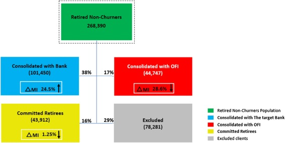

1. [Download : Download high-res image (202KB)](https://ars.els-cdn.com/content/image/1-s2.0-S0268401218301518-gr11_lrg.jpg)
2. [Download : Download full-size image](https://ars.els-cdn.com/content/image/1-s2.0-S0268401218301518-gr11.jpg)

Fig. 11. Schematic view of Retirement Consolidation Results.

After excluding 29% of this group with balances either less than $4000 or more than $10,000,000, the remaining clients were divided into three sub-groups: 17% of retired clients have already churned to other financial institutes and kept a low-level relationship with the target bank; 16% of clients fall under committed at risk who may or may not churn, depending on the future retention strategies. However, the remaining 38% demonstrated a high level of loyalty and consolidated all their investment with the target bank.

The result of this analysis is highly notable because as per our preliminary analysis and applying existing churn prediction techniques such as survival analysis, which is based on a binary method, only 8.7% of the retired population was identified as churned clients. However, after implementing the new model, based on big data analysis techniques and identified behavioral cues, the actual churn rate calculated as 24% of the entire retiree population.

The above finding is an indication of 175% improvement in accuracy of the result, which is highly remarkable for designing a successful retention strategy. As argued by (Verbeke et al., 2011), customer churn prediction models aim to detect customers with a high propensity to attrite. Predictive accuracy, comprehensibility, and justifiability are three key aspects of a churn prediction model. An accurate model allows for correctly targeting future churners in a retention marketing campaign, while a comprehensible and intuitive rule-set allows identifying the main drivers for customers to churn, and to develop an effective retention strategy in accordance with domain knowledge

### 6.2. Empirical results

The results of this study confirmed that clients' behavior has a significant correlation with their churn decision. This result was concluded after evaluating different behavioral cues, which are considered churn signals. Although mass affluent clients are twice more likely to retire after reaching the critical ages of 50, 55, 60 and 65; however their attrition rate is significantly lower than non-mass affluent clients. In the following sections, each hypothesis is discussed in more detail, referring to the statistical and correlation analysis which was conducted in SAS through a combination of T-Tests (Proc Freqs in SAS) and Anova (Proc GLM in SAS). The result of each hypothesis assessment is included in Appendix A and B.

**H1**

Churn rate has a significant correlation with the retirement event.

Based on the conducted analysis, this research supports the first hypothesis that the churn rate has a significant correlation with events of retirement. As discussed, the attrition rate significantly decreases after a retirement event occurs; however, as illustrated in Fig. 12, the churn rate spikes between year 2 and 3 after retirement amongst those who retired and then attired. It can be explained based on the fact that it generally takes one year for retirees to begin managing and enjoying the new chapter of their life, and usually, after year one, they begin to assess their investment portfolio to ensure it addresses all their retirement needs.

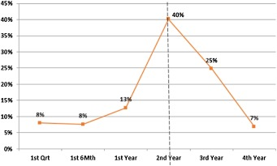

1. [Download : Download high-res image (91KB)](https://ars.els-cdn.com/content/image/1-s2.0-S0268401218301518-gr12_lrg.jpg)
2. [Download : Download full-size image](https://ars.els-cdn.com/content/image/1-s2.0-S0268401218301518-gr12.jpg)

Fig. 12. Trends for Attrition Post Retirement.

Referring to the result of the statistical analysis in Appendix A – Fig. A1, also confirms the significant correlation between churn and retirement events due to the result of Chi-Square and also P-Value equal to Zero. As seen in the frequency behavior, the churn rate prior to retirement is 14%, while this number remarkably decreases to 4.5% after retirement occurs. Fig. A2 in Appendix A shows the result of frequency and also normal probability plot in SAS, which indicates among retired and attrited clients, year 2 has the highest rate of attrition.

**H2**

The length of client history has a significant correlation with the churn rate.

Same as H<sub>1</sub>, the preliminary analysis also supported the H<sub>2</sub> hypothesis. As discussed earlier in this paper, the length and strength of a banking relationship have a significant correlation with churn decisions. This also can be concluded from the result of ANOVA test through the GLM procedure in SAS. As observed in Appendix A- Fig. A3, the correlation between attrition and tenure, which was considered as a dependent variable, is significantly high due to the P-Value being less than 0.0001. In this test, we have noticed some outliers in the data, which could have impacted the result; therefore, all the clients who have higher than 45 years’ of tenure were excluded from this analysis.

**H3**

**H4**

Customers’ online shopping behavior has a significant correlation with churn rate.

The results show that the attrition rate is not changed, based on the online usage within the retiree segment. Although, this study did not support H<sub>4;</sub> that online shopping behavior and the number of visits to retirement products have a significant relationship with the churn rate. However, as previously discussed, due to the nature of our population and the usage of online products, more online data and scrutiny is required before we can entirely reject this hypothesis.

**H5**

The type of shopping behavior has a significant correlation with the churn pattern.

In order to determine whether there is any difference between the churn rate of clients who use only online banking for their day-to-day activities and those who expand their usage to information seeking and research domains, some frequency tests were applied. Since the retirement universe of this study did not satisfy the required data for online usage, these T-tests were applied on not only retirement universe, but also the entire client base between November 1, 2014, and November 30, 2015.

Appendix B- Fig. B1 examines the attrition rate amongst all clients who used online banking, including transactions such as check balances and bill payments or seeking information and searching, such as looking at mortgage rates, using calculators, and so forth. In order to observe the relationship between the type of usage and attrition rates, while Fig. B2 focuses on clients who used online banking for transaction purposes only, Fig. B3 focuses on information seeking records.

As seen, the attrition rate amongst non-online clients is 7%, while this number drops to 1.6% between those who used online banking or information seeking pages. By comparing the results, it is concluded that attrition among those who used online channels for research is slightly less than those who used it only for day-to-day banking. The 0.3% difference is not significant to conclude that online activities and information seeking pages contribute to lower attrition rates.

### 6.3. Limitations and future directions

Similar to other studies, this study also faces some limitations. First and foremost because of the nature of our population, the available behavioral data related to clients' online research did not satisfy the result. The results of this study will be different in the next few years when the younger generation reaches their retirement stage, as the Internet and social media usage, in particular, is inevitable among this group.

The only pixel data that was procured for this study was the tracking of clients' visits through different retirement pages of target bank websites and the search engines to search for their desired products and services, therefore this study could have been more accurate if we could track our clients' online behavior through social media sites such as Facebook. There is a rich set of research articles covering the importance of social media in the context of business. For example, Pogrebnyakov and Maldonado (2018) point out that social media allow users to create content, establish connections with other users and share content with other users. They also offer several functionalities and characteristics, such as visibility of information, the establishment of connections and sharing of information and knowledge in the form of text, images, videos and web links among others. In particular, it has become an important driver for acquiring and spreading information in different business sectors today (Stieglitza, Mirbabaiea, Rossa, & Christoph Neubergerb, 2018). In this context, social media has been largely realized as an effective mechanism that contributes to the firms’ marketing aims and strategy; especially in the aspects relating to customer relationship management and communication (Alalwan, Rana, Dwivedi, & Raed, 2017; Alalwan, 2018); and the big data created through social media has secured a prominent position in almost all industries (Raginia, Anandb, & Bhaskar, 2018) including the financial institutes. However, the privacy implications for both customers and the target bank were one of the primary reasons for not compiling this type of data.

#### 6.3.1. Future directions

Few recommendations to the department of marketing and strategy of Personal and Commercial Banking (P&CB) of the target bank can be made, based on the findings of this study:

Designing and implementing different retention strategies for the retiree segment is another area for opportunity. If clients receive their customized and desired services and products when they most need it, they would be less likely to attrite after retirement. This will help to decrease the post-retirement attrition. Providing the right incentives to strengthen the banking relationship, especially amongst those clients who are new to the bank, is considered a key retention factor.

The need for a separate marketing campaign is necessary to encourage current non-retiree clients to improve or strengthen their banking relationship with the target bank. This can be achieved by offering different loyalty and rewards programs.

As confirmed, the constructed model has three months’ staying power. Therefore it is highly recommended to run the model every three months to; a) capture new entries to the population, b) evaluate the status of current clients and to compare the results by determining whether there have been any changes in churn decisions, especially amongst potential churners.

The Non-Retiree segment should also be analyzed using the MI data to distinguish true loyal clients from churners and potential churners. Since the current study is the first phase of an end-to-end Client Knowledge & Insights (CKI) analysis initiative, after implementing recommended retention strategies, the churn rate amongst those who were identified as potential churners should be measured to evaluate the success rate of this program.

The importance of discovering the right receptive point, which indicates when a specific client is naturally more receptive regarding retirement advice, should also be emphasized as part of future studies. This can be achieved by performing a sensitivity analysis and ascertaining out when the best time to tap into the mass market would be, in order to win the “moment of truth.”

## 7. Conclusion

The expected results of this study support the above hypotheses based on the identified backing and warrants. Subsequently, the main purpose of the conducted research supports the claim that offering the right product at the right moment can minimize churning. This study is also attempting to verify some sub-claims such as a) the number of visits to external websites is an indication of churn decisions and/or b) the longer a client has a history with a bank, the lower the likelihood of churn.

Since the Marketing and Strategy department within the Canadian Banking division of the target bank will consume the results of this study, this study also explores the time of the churn, relevant to the retirement date, in order to provide a clear roadmap for the marketing horizon.

Furthermore, this study scrutinizes the churn pattern of mass affluent clients versus non-mass affluent clients, to identify the right strategy for each market, which will maximize the rate of retention.

This study has several strengths. According to the current literature, it is the first study that uses CRT in conjunction with linear regression analysis for implementing the churn prediction model on big data, incorporating different sources of data such as pixel data, IVR logs, phone conversations, and financial data to examine the possibility of churn for each client. Utilizing a big [data analytics](https://www.sciencedirect.com/topics/social-sciences/data-analytics) tool such as Datameer for developing the current churn prediction model improved the result by 175% compared to traditional churn prediction models.

According to the conducted analysis, clients’ behavior has a significant correlation with churning decisions. This finding has a considerable impact on designing effective client relationship management strategies in the future because the higher the rate of accuracy in detecting and identifying potential churners, it will result in higher rates of success for more effective and efficient retention strategies.

This study confirms that mass-affluent clients are twice more likely to retire with the target bank and two times less likely to churn from the target bank. Although the attrition rate within mass affluent segments is notably lower than mass retail, as this segment owns a multi-billion dollar market, attrition or retention of clients within this segment has a significant impact in a bank’s profitability. Even though the churn rate significantly drops after retirement, but among those who attrite, most of the attrition occurs between years 2 and 3 after retirement.

Clients who have longer tenure and deeper banking relationships with the target bank are less likely to churn; therefore it is concluded that deepening the banking relationship will minimize the rate of attrition. “New to the bank” clients are more likely to maintain their relationship at the borrowing level or transaction only level. While borrowing only clients demonstrated high rates of interest to deepen their relationship after retirement, transaction only clients do not show any significant changes to their banking relationship and are most likely to churn after a while.

The online usage within the retiree segment did not show any correlation with the rate of attrition, due to low usage of online banking and information seeking channels by these particular clients.